# GO vs Wormcat

### Introduction

Presented below is a set of R commands for generating outputs of term enrichment analysis using topGO and comparing to Wormcat analysis. This GO analysis, using ‘topGO’, provides more flexibility than the approach using ‘goana’. More options for test statistics and algorithms are provided for running enrichment tests, and more functionality associated with the topGO class object allows for a comprehensive analysis.

**Input data for GO analysis**

*Option 1:*

-list of all genes with statistics from DGE analysis (p-value, logFC, adjusted p-value, etc.); this input option assumes that DGE analysis is performed prior to running this file  
-example dataset types include a likelihood ratio test output (i.e. from edgeR), a topTable output from limma/voom analysis, or any other gene list with associated statistics that may help in differentiating genes of interest from the entire gene list

*Option 2:*

-list of gene identifiers split up into two separate text files (without statistics):

- one that contains the entire gene list in the analysis (gene universe)
- one that contains a gene set of interest (predetermined gene list based on statistic(s) of interest; i.e., p-value from differential expression analysis, or identified hub genes), or any other qualitative measure)

*For the purpose of demonstration:*

- option 1 input data will be used for this analysis (group B vs group C differential expression analysis results in the form of an edgeR likelihood ratio test output)
- gene IDs are from Wormbase (i.e., “WBGene00000023”); *additional gene IDs can be provided in the* *test dataset if desired, such as entrez IDs or ensembl IDs, but wormbase is more comprehensive for* *this dataset*

**Input data for Wormcat analysis**

-files output from running “worm_cat_fun” in ‘Wormcat’ package (see ‘explore_wormcat.Rmd’ for details):

- category 1 term enrichment
- category 2 term enrichment
- category 3 term enrichment
- regulated gene set and category assignments

### topGO Analysis

**Read in appropriate packages for both analyses**

```r
if (!requireNamespace("BiocManager", quietly = TRUE))
  install.packages("BiocManager")

if(!require(biomaRt)) BiocManager::install("biomaRt")
if(!require(topGO)) BiocManager::install("topGO")
if(!require(org.Ce.eg.db)) BiocManager::install("org.Ce.eg.db")
if(!require(GO.db)) BiocManager::install("GO.db")

library(biomaRt)
library(org.Ce.eg.db)
library(GO.db)
library(topGO)
library(VennDiagram)
library(wormcat)
```

**Read in file for GO analysis**  
If utilizing the second option (see *Introduction*) for input data types, read in the two files containing the gene list for the analysis and the pre-determined set of interesting genes. The below file contains the output from edgeR’s likelihood ratio test.

```r
# read in the entire gene list for the analysis, not just the de genes; ideally a file from
# a likelihood ratio test which provides test statistics for differential expression
dge_data <- read.csv('worm_B_vs_C_lrt.csv',sep = ',',header = TRUE,row.names = 1)
head(dge_data)
```

```
##                     logFC   logCPM          LR     PValue
## WBGene00000001  0.0131464 6.393582 0.003774571 0.95101076
## WBGene00000002  0.1468424 1.780692 0.050212873 0.82269327
## WBGene00000003  0.8198194 1.830517 1.586825027 0.20778034
## WBGene00000004  0.7846646 3.557873 2.884785309 0.08941992
## WBGene00000005 -0.6566279 2.767732 1.504419715 0.21999257
## WBGene00000006  0.3221292 1.261145 0.173742778 0.67680668
```

**Assign gene list (universe) and gene set (genes of interest) to variables**  
This is necessary if using the first option for input data, which is the case for this analysis. Use this step to define the genes of interest based on whatever metric(s) is desired. If using the second option, gene identifiers would already be loaded in during the previous step for each category (gene list and gene set).

```r
# isolate all wormbase (or other) gene IDs from table
gene_list <- rownames(dge_data)
# subset the 'dge_data' dataframe by genes of interest, based on a single statistic
# or a combination of statistics (i.e., logFC >= 1 and P-value <= 0.05); capture the
# gene IDs for this set using 'rownames'; these are the genes defined as being
# differentially expressed
gene_set <- rownames(subset(dge_data, abs(logFC) >= 1 & PValue <= 0.05))
```

**Map GO terms to genes in the dataset**  
If using Wormbase gene IDs, the following two chunks of code are required, as the topGO class object does not support automated GO mappings to this identifier. This can be run for other ID types, such as entrez IDs or ensembl IDs (by changing the appropriate arguments), but these alternative ID mappings can be done when instantiating the topGO class object (see ‘topGO object’ code chunk).

```r
# generate gene to GO term mappings using biomaRt package
db <- useMart('ENSEMBL_MART_ENSEMBL',dataset='celegans_gene_ensembl', host="www.ensembl.org")
go_ids <- getBM(attributes=c('go_id', 'wormbase_gene', 'namespace_1003'), filters='wormbase_gene', values=gene_list, mart=db)
```

**Modify mapping output from ‘getBM’ so it’s compatible with topGO object**

```r
# modify annotation output for topGO object; gene to GO ID mapping object
gene_to_GO <- unstack(go_ids[,c(1,2)])
# check out the gene to GO term mappings
head(gene_to_GO)
```

```
## $WBGene00000001
##  [1] "GO:0016301" "GO:0016310" "GO:0046854" "GO:0005942" "GO:0008286"
##  [6] "GO:0043551" "GO:0046935" "GO:0019901" "GO:0008340" "GO:0040024"
##
## $WBGene00000002
## [1] "GO:0016020" "GO:0016021" "GO:0022857" "GO:0055085" "GO:1902475"
## [6] "GO:0005886" "GO:0015179" "GO:0003333" "GO:1990184"
##
## $WBGene00000003
## [1] "GO:0016020" "GO:0016021" "GO:0022857" "GO:0055085" "GO:0015179"
## [6] "GO:1902475"
##
## $WBGene00000004
## [1] "GO:0016020" "GO:0016021" "GO:0022857" "GO:0055085" "GO:1902475"
## [6] "GO:0005886" "GO:0015179" "GO:0003333" "GO:1990184"
##
## $WBGene00000005
## [1] "GO:0016020" "GO:0016021" "GO:0022857" "GO:0055085" "GO:0015179"
## [6] "GO:1902475" ""
##
## $WBGene00000006
## [1] "GO:0016020" "GO:0016021" "GO:0022857" "GO:0055085" "GO:0015179"
## [6] "GO:1902475" ""
```

**Get total number of interesting genes with annotations**  
For comparison of the total number of interesting genes (DEGs in this case) annotated to GO terms with that of those annotated to Wormcat terms, unique genes with mappings are counted.

```r
# pull out the total number of genes of interest that have a GO annotation; first subset
# by gene IDs with category annotations
with_annotations <- subset(go_ids,go_id != '')
# only consider one annotation instance for each gene
uniq_annots <- unique(with_annotations$wormbase_gene)
# identify the total number of annotated genes that are found in our gene set of interest
gene_set_annot <- intersect(gene_set,uniq_annots)
paste('Total number of differentially expressed genes w/GO annotations:',length(gene_set_annot))
```

```
## [1] "Total number of differentially expressed genes w/GO annotations: 808"
```

**Generate named vector for use with topGO class object instantiation**  
This creates a vector with gene IDs as the names for each element (Wormbase IDs in this case). This step is necessary for providing all genes as one object to be passed as an argument for the topGO class object. In this example scenario, genes of interest are marked with 1 while other genes in the analysis are marked with 0. If using a numeric vector, with a single statistic (p-value for example), a function can be applied to differentiate the interesting genes from the non-interesing genes in the topGO object call. Such an example is not provided herein.

```r
# obtain named vector representing all genes in analysis, with a factor level of '1'
# indicating gene of interest as defined in 'de_gene_set' and 0 if otherwise; this is
# required for the topGO class object instantiation
all_genes <- factor(as.integer(gene_list %in% gene_set))
# assign wormbase gene IDs for all genes to factor names
names(all_genes) <- gene_list
# check out the structure of the 'all_genes' object
str(all_genes)
```

```
##  Factor w/ 2 levels "0","1": 1 1 1 1 1 1 1 1 1 1 ...
##  - attr(*, "names")= chr [1:46882] "WBGene00000001" "WBGene00000002" "WBGene00000003" "WBGene00000004" ...
```

**Create topGO class objects for each of the three GO ontologies**  
These class objects are used for term enrichment analysis. The three ontologies associated with GO are biological process (BP), cellular component (CC), and molecular function (MF).

```r
# generate topGO object for analysis of the biological process (BP) ontology; using annotation
# function 'annFUN.gene2GO' due to mappings being provided; if mappings were not provided by user,
# see code commented out directly below this assignment
geneID2GO_bp <- new("topGOdata",         # specify topGO class
                 ontology="BP",          # choose ontology, options are "BP", "CC", and "MF"
                 allGenes = all_genes,   # specifies named vector with all genes in input data set
                 annot = annFUN.gene2GO, # function to perform gene to GO term mappings
                 gene2GO = gene_to_GO)   # mappings provided by user (see code chunks 4-5)
                 # use 'nodeSize=int' as an argument to set the minimum number of genes a GO term
                 # must have annotated to it for it to be included in the enrichment analysis; these
                 # terms with low numbers of annotated genes can be falsely detected as significantly enriched

# if gene IDs such as 'entrez' or 'ensembl' are provided in the input data sets, mappings
# from 'biomaRt' functionality (see lines 112-113) are not required and can be specified in
# the topGO class object call (essentially line 112-121 are not necessary):

# geneID2GO <- new("topGOdata", ontology="BP", allGenes = all_genes, annotationFun = annFUN.org, mapping = 'org.Ce.eg.db', ID = 'entrez')

# check out the details of the new topGO class object
geneID2GO_bp
```

```
##
## ------------------------- topGOdata object -------------------------
##
##  Description:
##    -
##
##  Ontology:
##    -  BP
##
##  46882 available genes (all genes from the array):
##    - symbol:  WBGene00000001 WBGene00000002 WBGene00000003 WBGene00000004 WBGene00000005  ...
##    - 1225  significant genes.
##
##  9622 feasible genes (genes that can be used in the analysis):
##    - symbol:  WBGene00000001 WBGene00000002 WBGene00000003 WBGene00000004 WBGene00000005  ...
##    - 470  significant genes.
##
##  GO graph (nodes with at least  1  genes):
##    - a graph with directed edges
##    - number of nodes = 6416
##    - number of edges = 14443
##
## ------------------------- topGOdata object -------------------------
```

```r
# get the topGO class object with annotations associated with 'CC' category
geneID2GO_cc <- new("topGOdata",
                 ontology="CC",          # choose 'CC' for ontology
                 allGenes = all_genes,
                 annot = annFUN.gene2GO,
                 gene2GO = gene_to_GO)
                 # use 'nodeSize=int' as an argument to set the minimum number of genes a GO term
                 # must have annotated to it for it to be included in the enrichment analysis

# check out the details of the new topGO class object (with the cellular compartment category)
geneID2GO_cc
```

```
##
## ------------------------- topGOdata object -------------------------
##
##  Description:
##    -
##
##  Ontology:
##    -  CC
##
##  46882 available genes (all genes from the array):
##    - symbol:  WBGene00000001 WBGene00000002 WBGene00000003 WBGene00000004 WBGene00000005  ...
##    - 1225  significant genes.
##
##  12170 feasible genes (genes that can be used in the analysis):
##    - symbol:  WBGene00000001 WBGene00000002 WBGene00000003 WBGene00000004 WBGene00000005  ...
##    - 604  significant genes.
##
##  GO graph (nodes with at least  1  genes):
##    - a graph with directed edges
##    - number of nodes = 1197
##    - number of edges = 2111
##
## ------------------------- topGOdata object -------------------------
```

```r
# now obtain the topGO class object with annotations associated with 'MF' category
geneID2GO_mf <- new("topGOdata",
                 ontology="MF",          # choose 'MF' for ontology
                 allGenes = all_genes,
                 annot = annFUN.gene2GO,
                 gene2GO = gene_to_GO)
                 # use 'nodeSize=int' as an argument to set the minimum number of genes a GO term
                 # must have annotated to it for it to be included in the enrichment analysis

# check out the details of the new topGO class object (with the molecular function category)
geneID2GO_mf
```

```
##
## ------------------------- topGOdata object -------------------------
##
##  Description:
##    -
##
##  Ontology:
##    -  MF
##
##  46882 available genes (all genes from the array):
##    - symbol:  WBGene00000001 WBGene00000002 WBGene00000003 WBGene00000004 WBGene00000005  ...
##    - 1225  significant genes.
##
##  10663 feasible genes (genes that can be used in the analysis):
##    - symbol:  WBGene00000001 WBGene00000002 WBGene00000003 WBGene00000004 WBGene00000005  ...
##    - 550  significant genes.
##
##  GO graph (nodes with at least  1  genes):
##    - a graph with directed edges
##    - number of nodes = 2677
##    - number of edges = 3477
##
## ------------------------- topGOdata object -------------------------
```

**Perform enrichment tests for each ontology category**  
Classic and weighted fisher tests are used to calculate enrichment of interesting genes in GO pathways. The difference between the two algorithms is that one considers the GO topology (weighted), while the other does not. In other words, p-values computed for a GO term are conditioned on the neighboring terms. Together, these tests provide additional information for interpretation.

```r
# perform enrichment tests for the BP ontology
# classic fisher test for over representation enrichment
classic_fisher_result_bp <- runTest(geneID2GO_bp, algorithm = 'classic', statistic = 'fisher')
# fisher test for enrichment using the weight01 algorithm, which takes into account the GO hierarchy
weight_fisher_result_bp <- runTest(geneID2GO_bp, algorithm = 'weight01', statistic = 'fisher')

# perform enrichment tests for the CC ontology
# classic fisher test for over representation enrichment
classic_fisher_result_cc <- runTest(geneID2GO_cc, algorithm = 'classic', statistic = 'fisher')
# fisher test for enrichment using the weight01 algorithm, which takes into account the GO hierarchy
weight_fisher_result_cc <- runTest(geneID2GO_cc, algorithm = 'weight01', statistic = 'fisher')

# perform enrichment tests for the MF ontology
# classic fisher test for over representation enrichment
classic_fisher_result_mf <- runTest(geneID2GO_mf, algorithm = 'classic', statistic = 'fisher')
# fisher test for enrichment using the weight01 algorithm, which takes into account the GO hierarchy
weight_fisher_result_mf <- runTest(geneID2GO_mf, algorithm = 'weight01', statistic = 'fisher')
```

**Create summary tables for the enrichment test results**

```r
# generate a summary table of the enrichment results for 'BP' ontology; store the top 20 results based on the weighted test
enrich_results_bp <- GenTable(geneID2GO_bp, classic = classic_fisher_result_bp, weight = weight_fisher_result_bp, orderBy = 'weight', ranksOf = 'classic', topNodes = 20)  # if all terms are desired in the table, pass
                                               # length(genesInTerm(geneID2GO)) to 'topNodes'
# display the first few terms
head(enrich_results_bp)
```

```
##        GO.ID                                  Term Annotated Significant
## 1 GO:0035335   peptidyl-tyrosine dephosphorylation       110          36
## 2 GO:0018105       peptidyl-serine phosphorylation       140          34
## 3 GO:0045087                innate immune response       278          46
## 4 GO:0006470             protein dephosphorylation       215          52
## 5 GO:0038083 peptidyl-tyrosine autophosphorylation        43          11
## 6 GO:0007060   male meiosis chromosome segregation         5           4
##   Expected Rank in classic classic  weight
## 1     5.37               2 7.7e-21 7.7e-21
## 2     6.84               6 2.7e-15 2.7e-15
## 3    13.58              14 1.6e-13 1.6e-13
## 4    10.50               1 8.7e-23 1.6e-06
## 5     2.10              27 4.7e-06 4.7e-06
## 6     0.24              28 2.7e-05 2.7e-05
```

```r
# generate a summary table of the enrichment results for 'CC' ontology; store the top 20 results based on the weighted test
enrich_results_cc <- GenTable(geneID2GO_cc, classic = classic_fisher_result_cc, weight = weight_fisher_result_cc, orderBy = 'weight', ranksOf = 'classic', topNodes = 20)  # if all terms are desired in the table, pass
                                               # length(genesInTerm(geneID2GO)) to 'topNodes'
# display the first few terms
head(enrich_results_cc)
```

```
##        GO.ID                                        Term Annotated Significant
## 1 GO:0031143                                pseudopodium        42          31
## 2 GO:0005856                                cytoskeleton       538          52
## 3 GO:0005737                                   cytoplasm      4218         213
## 4 GO:0043231    intracellular membrane-bounded organelle      4490         167
## 5 GO:0060102 collagen and cuticulin-based cuticle ext...        18           6
## 6 GO:0031234 extrinsic component of cytoplasmic side ...        69          11
##   Expected Rank in classic classic  weight
## 1     2.08               1 < 1e-30 < 1e-30
## 2    26.70               2 2.8e-06 2.1e-19
## 3   209.34              85 0.38942 6.8e-06
## 4   222.84             240 1.00000 6.5e-05
## 5     0.89               6 0.00016 0.00041
## 6     3.42               7 0.00054 0.00054
```

```r
# generate a summary table of the enrichment results for 'MF' ontology; store the top 20 results based on the weighted test
enrich_results_mf <- GenTable(geneID2GO_mf, classic = classic_fisher_result_mf, weight = weight_fisher_result_mf, orderBy = 'weight', ranksOf = 'classic', topNodes = 20)  # if all terms are desired in the table, pass
                                               # length(genesInTerm(geneID2GO)) to 'topNodes'
# display the first few terms
head(enrich_results_mf)
```

```
##        GO.ID                                        Term Annotated Significant
## 1 GO:0004725       protein tyrosine phosphatase activity       114          36
## 2 GO:0030246                        carbohydrate binding       310          42
## 3 GO:0004674    protein serine/threonine kinase activity       322          41
## 4 GO:0042302           structural constituent of cuticle       172          31
## 5 GO:0004722 protein serine/threonine phosphatase act...        63          15
## 6 GO:0004715 non-membrane spanning protein tyrosine k...        46          12
##   Expected Rank in classic classic  weight
## 1     5.88               3 2.0e-19 2.0e-19
## 2    15.99              10 7.5e-09 2.4e-08
## 3    16.61              13 6.8e-08 7.6e-08
## 4     8.87               9 7.8e-10 1.2e-07
## 5     3.25              14 4.9e-07 4.9e-07
## 6     2.37              15 2.4e-06 2.4e-06
```

```r
# produce a column containing the bonferroni corrected weighted values (FDR corrected) for each of the above tables
# for some reason the p-values are reported as string, not numeric
enrich_results_bp$classic <- as.numeric(enrich_results_bp$classic)
enrich_results_cc$classic <- as.numeric(enrich_results_cc$classic)
enrich_results_mf$classic <- as.numeric(enrich_results_mf$classic)
# add column with adjusted p-values (FDR corrected) to each table
enrich_results_bp$adj_pval_classic <- p.adjust(enrich_results_bp$classic,method = 'bonferroni',n = nrow(enrich_results_bp))
enrich_results_cc$adj_pval_classic <- p.adjust(enrich_results_cc$classic,method = 'bonferroni',n = nrow(enrich_results_cc))
enrich_results_mf$adj_pval_classic <- p.adjust(enrich_results_mf$classic,method = 'bonferroni',n = nrow(enrich_results_mf))
```

```r
# for each ontology results table, get all terms that are enriched at an adjusted p-value threshold (i.e., 0.05)
results_adjp_bp <- subset(enrich_results_bp,adj_pval_classic <= 0.05)
results_adjp_cc <- subset(enrich_results_cc,adj_pval_classic <= 0.05)
results_adjp_mf <- subset(enrich_results_mf,adj_pval_classic <= 0.05)
# show the first few lines of the updated results tables
head(results_adjp_bp)
```

```
##        GO.ID                                  Term Annotated Significant
## 1 GO:0035335   peptidyl-tyrosine dephosphorylation       110          36
## 2 GO:0018105       peptidyl-serine phosphorylation       140          34
## 3 GO:0045087                innate immune response       278          46
## 4 GO:0006470             protein dephosphorylation       215          52
## 5 GO:0038083 peptidyl-tyrosine autophosphorylation        43          11
## 6 GO:0007060   male meiosis chromosome segregation         5           4
##   Expected Rank in classic classic  weight adj_pval_classic
## 1     5.37               2 7.7e-21 7.7e-21         1.54e-19
## 2     6.84               6 2.7e-15 2.7e-15         5.40e-14
## 3    13.58              14 1.6e-13 1.6e-13         3.20e-12
## 4    10.50               1 8.7e-23 1.6e-06         1.74e-21
## 5     2.10              27 4.7e-06 4.7e-06         9.40e-05
## 6     0.24              28 2.7e-05 2.7e-05         5.40e-04
```

```r
head(results_adjp_cc)
```

```
##         GO.ID                                        Term Annotated Significant
## 2  GO:0005856                                cytoskeleton       538          52
## 5  GO:0060102 collagen and cuticulin-based cuticle ext...        18           6
## 6  GO:0031234 extrinsic component of cytoplasmic side ...        69          11
## 7  GO:0005581                             collagen trimer        56           9
## 15 GO:0005576                        extracellular region       632          57
## 19 GO:0031012                        extracellular matrix        94          17
##    Expected Rank in classic  classic  weight adj_pval_classic
## 2     26.70               2 2.80e-06 2.1e-19         0.000056
## 5      0.89               6 1.60e-04 0.00041         0.003200
## 6      3.42               7 5.40e-04 0.00054         0.010800
## 7      2.78               8 1.61e-03 0.00161         0.032200
## 15    31.37               5 7.80e-06 0.03846         0.000156
## 19     4.67               3 3.20e-06 0.09662         0.000064
```

```r
head(results_adjp_mf)
```

```
##        GO.ID                                        Term Annotated Significant
## 1 GO:0004725       protein tyrosine phosphatase activity       114          36
## 2 GO:0030246                        carbohydrate binding       310          42
## 3 GO:0004674    protein serine/threonine kinase activity       322          41
## 4 GO:0042302           structural constituent of cuticle       172          31
## 5 GO:0004722 protein serine/threonine phosphatase act...        63          15
## 6 GO:0004715 non-membrane spanning protein tyrosine k...        46          12
##   Expected Rank in classic classic  weight adj_pval_classic
## 1     5.88               3 2.0e-19 2.0e-19         4.00e-18
## 2    15.99              10 7.5e-09 2.4e-08         1.50e-07
## 3    16.61              13 6.8e-08 7.6e-08         1.36e-06
## 4     8.87               9 7.8e-10 1.2e-07         1.56e-08
## 5     3.25              14 4.9e-07 4.9e-07         9.80e-06
## 6     2.37              15 2.4e-06 2.4e-06         4.80e-05
```

**Get all genes and significant genes associated with statistically enriched terms**

```r
# get all genes that are associated with an enriched term; perform for each ontology
GO_genes_bp <- genesInTerm(geneID2GO_bp)
GO_genes_cc <- genesInTerm(geneID2GO_cc)
GO_genes_mf <- genesInTerm(geneID2GO_mf)
# get significant genes that are associated with a GO term; perform for each ontology
sig_genes_bp <- sigGenes(geneID2GO_bp)
sig_genes_cc <- sigGenes(geneID2GO_cc)
sig_genes_mf <- sigGenes(geneID2GO_mf)
```

**Add the significant gene IDs to each results table as a column**

```r
# add list of significant genes associated with significantly enriched GO terms to each table above as separate column
results_adjp_bp$Significant_Genes <- sapply(results_adjp_bp$GO.ID, function(x){
  genes <- GO_genes_bp[x][[1]]
  genes[genes %in% sig_genes_bp]
})
results_adjp_cc$Significant_Genes <- sapply(results_adjp_cc$GO.ID, function(x){
  genes <- GO_genes_cc[x][[1]]
  genes[genes %in% sig_genes_cc]
})
results_adjp_mf$Significant_Genes <- sapply(results_adjp_mf$GO.ID, function(x){
  genes <- GO_genes_mf[x][[1]]
  genes[genes %in% sig_genes_mf]
})
```

**Reformat significant gene IDs column so tables can be written out as csv**  
The gene IDs are added as a comma separated list, for use in further analyses if desired.

```r
# reformat the data in the significant gene list column just created; do so for each ontology's results table
for (i in 1:length(results_adjp_bp$Significant_Genes)) {
  results_adjp_bp$Significant_Genes[[i]] <- paste(unlist(results_adjp_bp$Significant_Genes[[i]]),sep = '',collapse = ', ')
}
for (i in 1:length(results_adjp_cc$Significant_Genes)) {
  results_adjp_cc$Significant_Genes[[i]] <- paste(unlist(results_adjp_cc$Significant_Genes[[i]]),sep = '',collapse = ', ')
}
for (i in 1:length(results_adjp_mf$Significant_Genes)) {
  results_adjp_mf$Significant_Genes[[i]] <- paste(unlist(results_adjp_mf$Significant_Genes[[i]]),sep = '',collapse = ', ')
}

# change data type from list to character so results can be written out to file
results_adjp_bp$Significant_Genes <- as.character(results_adjp_bp$Significant_Genes)
results_adjp_cc$Significant_Genes <- as.character(results_adjp_cc$Significant_Genes)
results_adjp_mf$Significant_Genes <- as.character(results_adjp_mf$Significant_Genes)
```

**Write out enrichment results for each GO ontology category to csv**

```r
# write results out to csv file for each ontology
write.csv(results_adjp_bp,'BvsC_term_enrichment_results_bp.csv')
write.csv(results_adjp_cc,'BvsC_term_enrichment_results_cc.csv')
write.csv(results_adjp_mf,'BvsC_term_enrichment_results_mf.csv')
```

### Wormcat Analysis

**Read in the category mapping to genes file from Wormcat output**  
This is the comprehensive file containing the mapping of category information to each input gene. Categories 1, 2, and 3 are provided for each gene, as well as a more detailed annotation of the putative gene function.

```r
# read in file
wormcat_mappings <- read.csv('B_vs_C_rgs_and_categories.csv',row.names = 1,header = TRUE)
# remove the genes with 'Unknown' category 1 assignments; not useful for term enrichment analysis or
# comparison to GO
wc_annotations <- subset(wormcat_mappings,Category.1 != 'Unknown')
# get the total genes annotated to useful category terms
paste('Total number of differentially expressed genes w/Wormcat category annotations:',length(wc_annotations$Wormbase.ID))
```

```
## [1] "Total number of differentially expressed genes w/Wormcat category annotations: 700"
```

**Generate a venn diagram**  
This venn shows the relationship between interesting genes annotated by each of GO and Wormcat. This diagram pulls from a variable generated in code chunk ‘annotation count’.

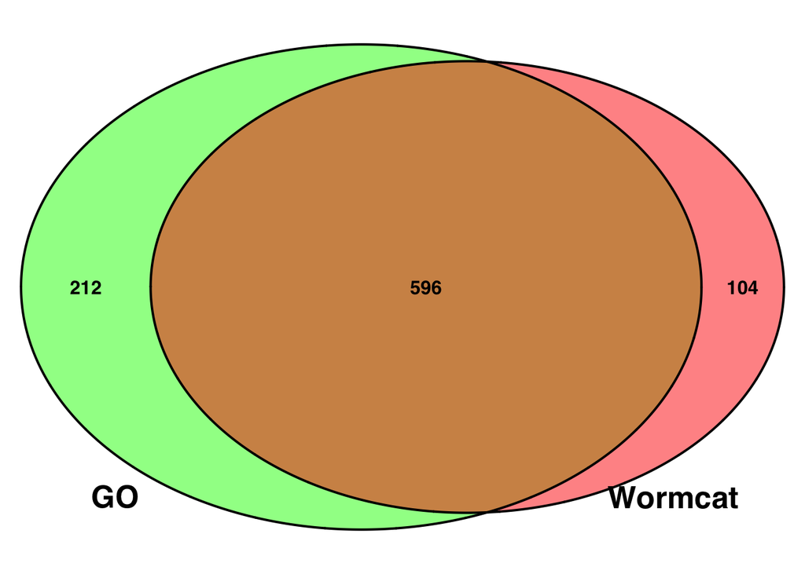

```r
venn <- venn.diagram(
  x = list(gene_set_annot, wc_annotations$Wormbase.ID),
  category.names = c("GO" , "Wormcat"),
  filename = NULL,
  lwd=2,
  fill=c('green','red'),
  cex=1,
  fontface='bold',
  fontfamily='sans',
  cat.cex=1.6,
  cat.pos = c(220, 145),
  cat.fontface='bold',
  cat.fontfamily = "sans"
)
grid.newpage()
grid.draw(venn)
```

Overall, the differences observed in the Venn Diagram above are a result of the removal of any “Unknown” Wormcat assignments from category 1. These results demonstrate the usefulness of utilizing both GO and Wormcat for term enrichment analysis, as both platforms contain a handful of useful gene ontolgy annotations that are not defined in the other (i.e., 212 extra annotations found in GO that are “Unknown” in Wormcat, and 104 extra annotations found in Wormcat that are absent in GO). Although the genes annotated to “Unknown” categories don’t provide useful information for gene ontology enrichment analysis, the refined “automated descriptions” associated with each could be useful pieces of information for downstream analyses where individuals genes (hub genes identified using WGCNA?) are selected for further analysis.

### Conclusion

With topGO, term enrichment analysis is more flexible in its testing abilities, has extensive functionality to make interpreting enrichment analysis easy, and can still provide some important information that Wormcat lacks (i.e, category annotations for certain genes). Wormcat, on the other hand, provides more specific functional details for genes that lack term annotations through GO methods. These details might prove useful for more fine tuned analyses looking at gene leads putatively associated with a phenotype under a specific treatment. Together, separate topGO and Wormcat analyses might be useful for the reasons previously described. Significantly enriched terms for each system can be compared and help to make more informed decisions, while the detailed Wormcat annotations can be extracted for further analysis (potentially with WGCNA output?)

### Functional Annotation of WGCNA Modules

Maybe this pipeline (in its original or modified form) could be used for functional enrichment analysis of gene modules? Not sure how that would look for the time being, but possible gene lists would be all genes in a given analysis while the interesting genes are the entire gene set within a module. If the gene set within a module is too large for a term enrichment analysis, then maybe the gene set can be parsed down to differentially expressed genes within a module, or hub genes (i.e., genes that drive the significance of the module most).

### References

[topGO link](https://bioconductor.org/packages/release/bioc/vignettes/topGO/inst/doc/topGO.pdf)